# PISA 2012 Data Exploration

## About PISA

The OECD Programme for International Student Assessment (PISA) surveys, which take place every threeyears, have been designed to collect information about 15-year-old students in participating countries. PISA examines how well students are prepared to meet the challenges of the future, rather than how well they master particular curricula.

## Research questions and methodology

Mathematics is an intense subject. Apart from crunching numbers in mind or in calculator, there are various other factors like support from parents and teachers, play an important role in scoring good grades. Not just external support, but how interesting a student find subject, is also of utmost importance. In this document, I will explore the cause and relationship among students scoring mathematics to answer the following questions:

- What is the attitude of students towards scoring high scores in math?
- How parents' education level and occupational status play a role in students’ academia?
- How teachers support their students in advance in their academia?

## About dataset

This dataset contains 172491 rows and 636 columns. Out of 636 variables, the following variables are shortlisted for the purpose of exploration:

1. CNT : Country
2. ST04Q01 : Gender
3. AGE : Age of student
4. HISCED : Highest educational level of parents**
5. HISEI : Highest parental occupational status
6. ANXMAT : Mathematics Anxiety
7. INSTMOT : Instrumental Motivation for Mathematics
8. INTMAT : Mathematics Interest
9. MATBEH : Mathematics Behavior
10. MATHEFF : Mathematics Self-Efficacy
11. MATINTFC : Mathematics Intentions
12. MATWKETH : Mathematics Work Ethic
13. MMINS : Learning time (minutes per week)
14. MTSUP : Mathematics Teacher's Support
15. INFOCAR : Information about Careers
16. STUDREL : Teacher Student Relations
17. PV1MATH : Math score

** [Indices on parental education](https://www.oecd.org/pisa/pisaproducts/PISA%202012%20Technical%20Report_Chapter%2016.pdf) were constructed by recoding educational qualifications into the following categories:

- (0) None
- (1) ISCED 1 (primary education)
- (2) ISCED 2 (lower secondary)
- (3) ISCED Level 3B or 3C (vocational/pre-vocational upper secondary)
- (4) ISCED 3A (general upper secondary) and/or ISCED 4 (non-tertiary post-secondary)
- (5) ISCED 5B (vocational tertiary) and
- (6) ISCED 5A, 6 (theoretically oriented tertiary and post-graduate).

# Data Exploration

```python
## Load relevant packages
import pandas                  as pd
import numpy                   as np
import matplotlib.pyplot       as plt
import seaborn                 as sns

%matplotlib inline
plt.style.use('ggplot')
```

```python
#read csv file
df = pd.read_csv('pisa2012-b.csv', engine = "python", sep = ',')
df.head()
```

|  | Unnamed: 0 | CNT | SUBNATIO | STRATUM | OECD | NC | SCHOOLID | STIDSTD | ST01Q01 | ST02Q01 | ... | W_FSTR75 | W_FSTR76 | W_FSTR77 | W_FSTR78 | W_FSTR79 | W_FSTR80 | WVARSTRR | VAR_UNIT | SENWGT_STU | VER_STU |
| --- | --- | --- | --- | --- | --- | --- | --- | --- | --- | --- | --- | --- | --- | --- | --- | --- | --- | --- | --- | --- | --- |
| 0 | 179163 | Finland | 2460000 | FIN0007 | OECD | Finland | 124 | 3488 | 9 | 1 | ... | 4.1562 | 25.9485 | 25.9485 | 4.1562 | 4.1562 | 25.9485 | 59.0 | 1.0 | 0.2472 | 22-Nov-13 |
| 1 | 179164 | Finland | 2460000 | FIN0007 | OECD | Finland | 124 | 3489 | 9 | 1 | ... | 4.1562 | 25.9485 | 25.9485 | 4.1562 | 4.1562 | 25.9485 | 59.0 | 1.0 | 0.2472 | 22-Nov-13 |
| 2 | 179165 | Finland | 2460000 | FIN0007 | OECD | Finland | 124 | 3490 | 9 | 1 | ... | 4.0200 | 23.4300 | 23.4300 | 4.0200 | 4.0200 | 23.4300 | 59.0 | 1.0 | 0.2286 | 22-Nov-13 |
| 3 | 179166 | Finland | 2460000 | FIN0007 | OECD | Finland | 124 | 3491 | 9 | 1 | ... | 4.1562 | 25.9485 | 25.9485 | 4.1562 | 4.1562 | 25.9485 | 59.0 | 1.0 | 0.2472 | 22-Nov-13 |
| 4 | 179167 | Finland | 2460000 | FIN0007 | OECD | Finland | 124 | 3492 | 9 | 1 | ... | 4.0200 | 23.4300 | 23.4300 | 4.0200 | 4.0200 | 23.4300 | 59.0 | 1.0 | 0.2286 | 22-Nov-13 |

5 rows × 636 columns

```python
df.shape
```

```
(172491, 636)
```

```python
#Create another dataframe with selected variables
df1 = df[['CNT', 'ST04Q01','AGE','HISCED','HISEI','ANXMAT','INSTMOT','INTMAT','MATBEH','MATHEFF','MATINTFC','MATWKETH','MMINS','MTSUP',
              'INFOCAR','STUDREL','PV1MATH']]
df1
```

|  | CNT | ST04Q01 | AGE | HISCED | HISEI | ANXMAT | INSTMOT | INTMAT | MATBEH | MATHEFF | MATINTFC | MATWKETH | MMINS | MTSUP | INFOCAR | STUDREL | PV1MATH |
| --- | --- | --- | --- | --- | --- | --- | --- | --- | --- | --- | --- | --- | --- | --- | --- | --- | --- |
| 0 | Finland | Male | 16.00 | ISCED 5A, 6 | 68.70 | -1.00 | NaN | NaN | NaN | NaN | NaN | NaN | 90.0 | -1.6333 | 0.8708 | -0.02 | 601.6591 |
| 1 | Finland | Male | 15.75 | ISCED 5B | 56.00 | -0.20 | NaN | NaN | NaN | NaN | NaN | NaN | 90.0 | -1.1894 | -0.2566 | -0.48 | 550.3272 |
| 2 | Finland | Female | 15.75 | ISCED 5B | 53.15 | -2.37 | 0.80 | 0.58 | -0.4567 | 0.54 | 1.4565 | -0.4017 | NaN | -0.6577 | 0.4984 | 2.16 | 631.1809 |
| 3 | Finland | Male | 15.67 | ISCED 1 | 26.62 | NaN | 0.05 | -0.66 | -2.1402 | 1.07 | -0.1191 | -1.1886 | 225.0 | NaN | 0.8066 | NaN | 484.7406 |
| 4 | Finland | Female | 15.58 | ISCED 5A, 6 | 17.79 | NaN | 1.59 | 0.00 | -0.4567 | 0.78 | -0.2514 | -1.1886 | 225.0 | NaN | 0.8708 | NaN | 670.8288 |
| ... | ... | ... | ... | ... | ... | ... | ... | ... | ... | ... | ... | ... | ... | ... | ... | ... | ... |
| 172486 | Montenegro | Female | 15.92 | ISCED 3A, ISCED 4 | 19.78 | 0.32 | 0.05 | -1.78 | -2.1402 | -1.36 | -1.5329 | -1.1886 | NaN | -1.4093 | NaN | -0.02 | 429.1245 |
| 172487 | Montenegro | Male | 15.83 | ISCED 5B | 56.00 | NaN | -0.67 | 0.00 | 0.8153 | -0.18 | NaN | -2.1448 | 180.0 | NaN | NaN | NaN | 413.0005 |
| 172488 | Montenegro | Female | 16.08 | ISCED 5A, 6 | 58.77 | -1.30 | 0.50 | 1.51 | 0.8110 | -0.77 | 0.6584 | 1.4298 | NaN | 0.6709 | NaN | -0.02 | 407.7816 |
| 172489 | Montenegro | Male | 16.17 | ISCED 5B | NaN | 0.56 | -1.12 | -0.34 | -1.0226 | -0.48 | -0.7332 | -0.5641 | NaN | 1.1169 | NaN | -1.04 | 397.7333 |
| 172490 | Montenegro | Female | 15.67 | ISCED 5B | 25.26 | NaN | -1.12 | -0.66 | 0.2171 | -0.63 | -0.7332 | -0.5641 | 180.0 | NaN | NaN | NaN | 399.5248 |

172491 rows × 17 columns

```python
#Rename columns
df1.rename(columns = {'CNT':'Country' , 'ST04Q01': 'gender','HISCED': 'parents_education', 'AGE':'age' , 'HISEI' : 'parents_occupational_status',
                     'ANXMAT' :'anxiety_score', 'INSTMOT' : 'motivation_score', 'INTMAT' : 'interest_score', 'MATBEH': 'behaviour_score',
                      'MATHEFF': 'efficacy_score', 'MATINTFC': 'intention_score', 'MATWKETH': 'work_ethic_score' , 'MMINS' : 'learning_time_min',
                      'MTSUP': 'teacher_support_score', 'INFOCAR': 'career_info_score', 'STUDREL' : 'stu_teach_relation_score' ,
                       'PV1MATH': 'math_score'}, inplace = True)
```

```python
df1.info()
```

```
<class 'pandas.core.frame.DataFrame'>
RangeIndex: 172491 entries, 0 to 172490
Data columns (total 17 columns):
Country                        172491 non-null object
gender                         172491 non-null object
age                            172405 non-null float64
parents_education              168415 non-null object
parents_occupational_status    162440 non-null float64
anxiety_score                  113287 non-null float64
motivation_score               113426 non-null float64
interest_score                 113519 non-null float64
behaviour_score                112914 non-null float64
efficacy_score                 113343 non-null float64
intention_score                108445 non-null float64
work_ethic_score               113034 non-null float64
learning_time_min              103757 non-null float64
teacher_support_score          112990 non-null float64
career_info_score              73671 non-null float64
stu_teach_relation_score       113062 non-null float64
math_score                     172491 non-null float64
dtypes: float64(14), object(3)
memory usage: 22.4+ MB
```

```python
#Convert parent education into category variable in an orderly fashion
level_order = ['None', 'ISCED 1 ', 'ISCED 2', 'ISCED 3B, C' , 'ISCED 3A, ISCED 4', 'ISCED 5B', 'ISCED 5A, 6']
ordered_cat = pd.api.types.CategoricalDtype(ordered = True, categories = level_order)
df1['parents_education'] = df1['parents_education'].astype(ordered_cat)
```

```python
#Check null values
df1.isnull().sum()
```

```
Country                            0
gender                             0
age                               86
parents_education              12204
parents_occupational_status    10051
anxiety_score                  59204
motivation_score               59065
interest_score                 58972
behaviour_score                59577
efficacy_score                 59148
intention_score                64046
work_ethic_score               59457
learning_time_min              68734
teacher_support_score          59501
career_info_score              98820
stu_teach_relation_score       59429
math_score                         0
dtype: int64
```

```python
#Fill Nan values with mean
df1.fillna(df1.mean(), inplace=True)
```

```python
#Drop Nan values for categorical variables
df1.dropna(inplace = True)
```

```python
df1.isnull().sum()
```

```
Country                        0
gender                         0
age                            0
parents_education              0
parents_occupational_status    0
anxiety_score                  0
motivation_score               0
interest_score                 0
behaviour_score                0
efficacy_score                 0
intention_score                0
work_ethic_score               0
learning_time_min              0
teacher_support_score          0
career_info_score              0
stu_teach_relation_score       0
math_score                     0
dtype: int64
```

```python
#Check descriptive statistics
df1.describe()
```

|  | age | parents_occupational_status | anxiety_score | motivation_score | interest_score | behaviour_score | efficacy_score | intention_score | work_ethic_score | learning_time_min | teacher_support_score | career_info_score | stu_teach_relation_score | math_score |
| --- | --- | --- | --- | --- | --- | --- | --- | --- | --- | --- | --- | --- | --- | --- |
| count | 160287.000000 | 160287.000000 | 160287.000000 | 160287.000000 | 160287.000000 | 160287.000000 | 160287.000000 | 160287.000000 | 160287.000000 | 160287.000000 | 160287.000000 | 160287.000000 | 160287.000000 | 160287.000000 |
| mean | 15.753309 | 49.114137 | 0.186765 | 0.081865 | 0.200822 | 0.185409 | -0.060400 | -0.030374 | 0.123081 | 221.905376 | 0.173521 | -0.196373 | 0.107929 | 475.384871 |
| std | 0.287585 | 21.238324 | 0.757140 | 0.803143 | 0.815300 | 0.842651 | 0.771965 | 0.777306 | 0.818495 | 66.374748 | 0.812884 | 0.631163 | 0.842551 | 97.468609 |
| min | 15.170000 | 11.010000 | -2.370000 | -2.300000 | -1.780000 | -2.140200 | -3.750000 | -1.532900 | -3.450300 | 0.000000 | -2.864500 | -2.307400 | -3.110000 | 95.194000 |
| 25% | 15.500000 | 29.470000 | 0.060000 | -0.390000 | 0.000000 | -0.072100 | -0.330000 | -0.251400 | -0.235600 | 200.000000 | -0.239500 | -0.200905 | -0.020000 | 405.990000 |
| 50% | 15.750000 | 47.987161 | 0.191249 | 0.088606 | 0.212762 | 0.187648 | -0.069897 | -0.027857 | 0.126341 | 222.350000 | 0.177306 | -0.200905 | 0.114607 | 472.121800 |
| 75% | 16.000000 | 68.700000 | 0.560000 | 0.500000 | 0.580000 | 0.448600 | -0.020000 | 0.177500 | 0.288200 | 225.000000 | 0.248600 | -0.200905 | 0.450000 | 542.304100 |
| max | 16.330000 | 88.960000 | 2.550000 | 1.590000 | 2.290000 | 4.424900 | 2.270000 | 1.456500 | 2.716700 | 2200.000000 | 1.843300 | 2.784600 | 2.160000 | 891.346000 |

## Univariate exploration

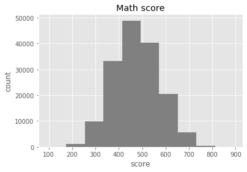

```python
#Plot histogram for math score
plt.hist(df1.math_score, color = 'grey')
plt.title('Math score')
plt.xlabel('score')
plt.ylabel('count');
```

> The math score is normally distributed.

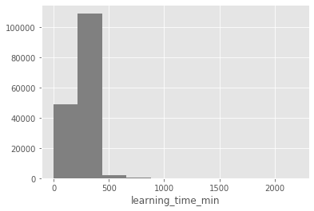

```python
#Plot histogram for learning time
plt.hist(df1.learning_time_min, color = 'grey');
plt.xlabel('learning_time_min')
plt.show()
```

> The graph is right skewed distribution. Looking at the graph and descriptive statistics above, one can say that there is a presence of outliers. At this moment I will remove the outlier by setting quantiles 0.01 to 0.99 and see the distribution changes.

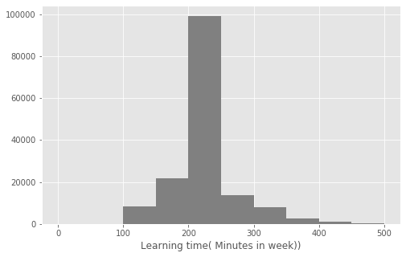

```
''
```

```python
##Remove outlier
#Set quantiles 0.01 to 0.99
q_low = df1["learning_time_min"].quantile(0.01)
q_hi  = df1["learning_time_min"].quantile(0.99)
q_low
df2 = df1[(df1["learning_time_min"] < q_hi) & (df1["learning_time_min"] > q_low)]


#Plot histogram
binsize = 50
bins = np.arange(0, df2['learning_time_min'].max()+binsize, binsize)

plt.figure(figsize=[8, 5])
plt.hist(data = df2, x = 'learning_time_min', bins = bins, color = 'grey')
plt.xlabel('Learning time( Minutes in week))')
plt.show()
;
```

> The distribution looks normal now.

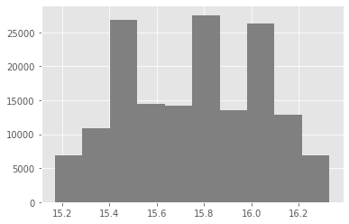

```python
#Plot histogram to see age of the students
plt.hist(df1.age, color = 'grey');
```

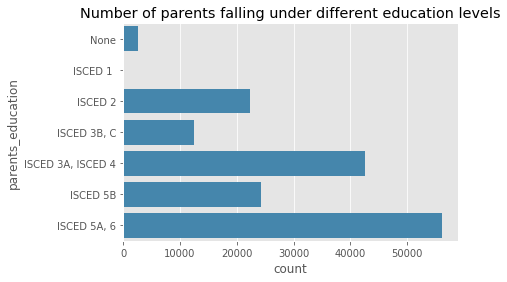

```python
#Plot bar graph to see number of parents falling under different education levels
base_color = sns.color_palette()[1]
sns.countplot(data = df1, y = 'parents_education', color = base_color)
plt.title("Number of parents falling under different education levels")
```

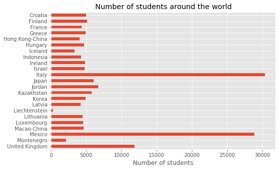

```python
#Plot bar graph to see number of students around the world
plt.figure(figsize=[8, 5])
df1['Country'].value_counts().sort_index(ascending=False).plot.barh()
plt.title("Number of students around the world")
plt.xlabel("Number of students");
```

> Most of the participants are form Italy and Mexico. Liechtenstein has very few participants.